# OWA CTmax lineages

Rowan Batts

2025-10-13

```r
knitr::opts_chunk$set(echo = TRUE)
knitr::opts_chunk$set(message = FALSE, warning = FALSE)
options(dplyr.summarise.inform = FALSE)

lineage_cols = c("AM" = "#0C7BDF",
                 "OA" = "#009D77",
                 "OW" = "#FFA602",
                 "OWA" = "#D55D07")

#this changes lab codes of HH,HA,AH,AA to OW, OWA, OA, AM for easy of understanding for the audience and parses the experimental conditions e.g. OW-AM-4 into its components
full_data <-  full_data %>%
    mutate(lineage= str_replace_all(lineage,"HH", "OWA"),
        lineage= str_replace_all(lineage, "HA", "OW"),
        lineage= str_replace_all(lineage, "AH", "OA"),
        lineage= str_replace_all(lineage, "AA", "AM")) %>%
  mutate(treatment = str_split_i(lineage, pattern = "-", i = 1),
         ancestral = ifelse(grepl("-",lineage),
                            str_split_i(lineage, pattern = "-", i = 2),lineage),
         replicate_ID = paste(ancestral,replicate, sep="-"))
```

# Ramping Rate

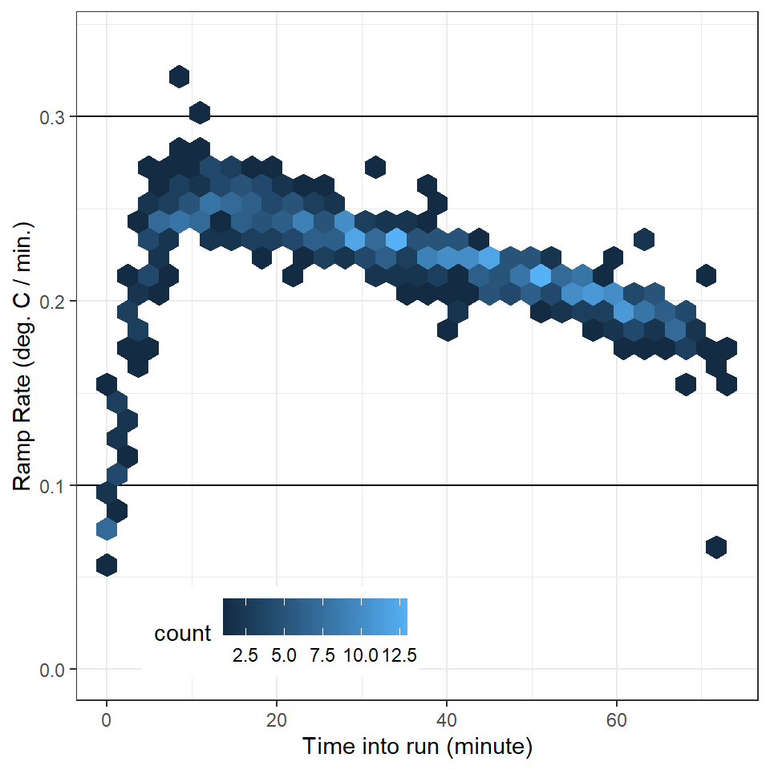

```r
ramp_record2 = ramp_record %>%
  group_by(run, minute_interval) %>%
  summarise(mean_ramp = mean(ramp_per_minute)) %>%
  drop_na(minute_interval, mean_ramp)
ggplot(ramp_record2, aes(x = minute_interval, y = mean_ramp)) +
  geom_hline(yintercept = 0.3) +
  geom_hline(yintercept = 0.1) +
  geom_hex(bins = 30) +
  ylim(0,0.34) +
  labs(y = "Ramp Rate (deg. C / min.)",
       x = "Time into run (minute)") +
 theme_bw()+
  theme(legend.position = c(0.3, 0.1),
        legend.direction = "horizontal")
```

# Identifying outliers

Individuals with a z-score of less than -3 or greater than +3 are excluded from all analysis. Outliers are displayed below.

```r
outliers <- full_data %>%
  group_by(data_set, lineage) %>%
  mutate(
    ctmax_mean = mean(ctmax, na.rm = TRUE),
    ctmax_sd = sd(ctmax, na.rm = TRUE),
    ctmax_z = (ctmax - ctmax_mean) / ctmax_sd) %>%
  filter(ctmax_z^2>9) %>%
  dplyr::select(data_set, lineage, treatment, ctmax_z)

kable(outliers)
```

| data_set | lineage | treatment | ctmax_z |
| --- | --- | --- | --- |
| 4_lineages | AM | AM | -3.084084 |
| AM-OA | OA-OA | OA | -3.112973 |
| OW-OWA | OW-OWA | OW | -3.691125 |

```r
full_data <- full_data %>%
  group_by(data_set, lineage) %>%
  mutate(
    ctmax_mean = mean(ctmax, na.rm = TRUE),
    ctmax_sd = sd(ctmax, na.rm = TRUE),
    ctmax_z = (ctmax - ctmax_mean) / ctmax_sd) %>%
  filter(ctmax_z^2<9) %>%
  dplyr::select(-ctmax_mean, -ctmax_sd)
```

```r
am_ow <- full_data %>%
  filter(data_set == "AM-OW")

lineages <- full_data %>%
  filter(data_set == "4_lineages") %>%
  mutate(ancestral = treatment) %>%
  mutate(temp = str_split_i(lineage, pattern = "", i = 1),
         co2 = str_split_i(lineage, pattern = "", i = 2),
         temp = if_else(lineage == "OW" | lineage == "OWA", "High", "Ambient"),
         co2 = if_else(lineage == "OW=A" | lineage == "OWA", "High", "Ambient"))

am_oa <- full_data %>%
  filter(data_set == "AM-OA")

ow_owa <- full_data %>%
  filter(data_set == "OW-OWA")

#Excludes extra trials
use_am_oa <- am_oa
use_am_ow <- am_ow
use_ow_owa <- ow_owa
```

# CTmax under source conditions

### Sample Size

```r
lineages %>%
  count(lineage) %>%
  knitr::kable()
```

| data_set | lineage | n |
| --- | --- | --- |
| 4_lineages | AM | 16 |
| 4_lineages | OA | 21 |
| 4_lineages | OW | 22 |
| 4_lineages | OWA | 20 |

### Length

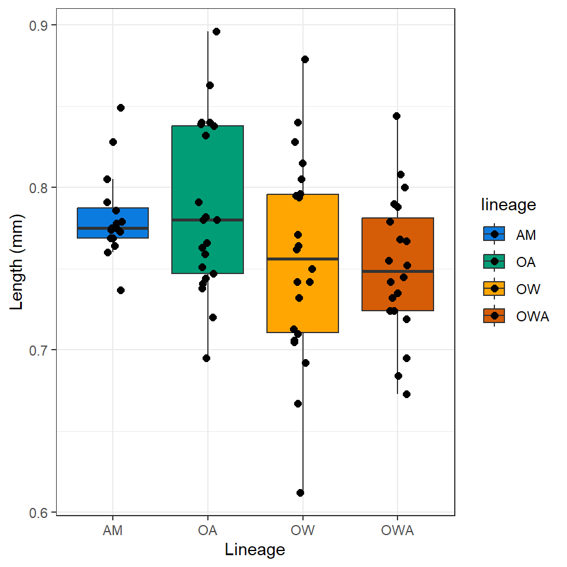

```r
ggplot(lineages, aes(x = lineage, y = length, fill = lineage)) +
  geom_boxplot(outlier.colour = NA) +
  geom_point(size = 2, position = position_jitter(width = 0.1, height = 0)) +
  scale_fill_manual(values = lineage_cols) +
  labs(x = "Lineage",
       y = "Length (mm)") +
  theme(legend.position = "none")+
  theme_bw()
```

The smallest individual (length ~ 0.6mm) is excluded from analyses due to the likelihood it was not a mature individual.

```r
lineages <- lineages %>%
   filter(length > 0.65)
```

```r
leveneTest(length~lineage, lineages)
```

```
## Levene's Test for Homogeneity of Variance (center = median)
##       Df F value  Pr(>F)
## group  3  3.4796 0.02007 *
##       74
## ---
## Signif. codes:  0 '***' 0.001 '**' 0.01 '*' 0.05 '.' 0.1 ' ' 1
```

```r
kruskal.test(length ~ lineage, lineages)
```

```
##
##  Kruskal-Wallis rank sum test
##
## data:  length by lineage
## Kruskal-Wallis chi-squared = 6.4658, df = 3, p-value = 0.09102
```

```r
lineages_means <- lineages %>%
  group_by(lineage) %>%
  mutate(mean=mean(length),median=median(length)) %>%
  dplyr::select(lineage,mean,median) %>%
  unique()
```

### CTmax

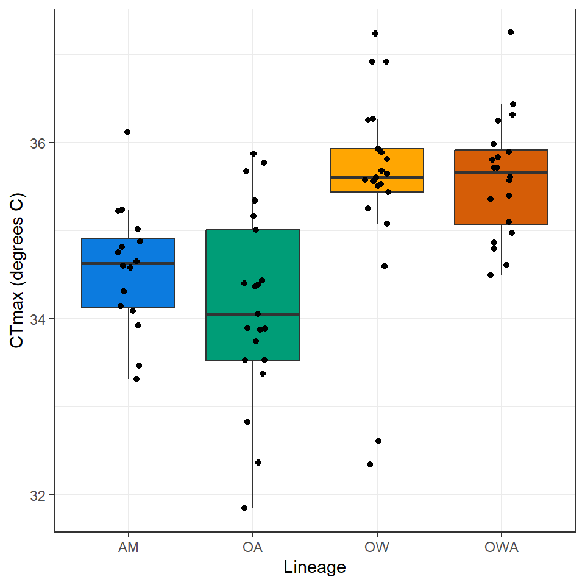

```r
ggplot(lineages, aes(x = lineage, y = ctmax, fill = lineage)) +
  geom_boxplot(outlier.colour = NA) +
  geom_point(position = position_jitter(width = 0.1, height = 0)) +
  scale_fill_manual(values = lineage_cols) +
  labs(x = "Lineage",
       y = "CTmax (degrees C)") +
  theme_bw()+
  theme(legend.position = "none")
```

```r
lineages$temp <- as.factor(lineages$temp)
lineages$co2 <- as.factor(lineages$co2)

ctmax.model.lineages = lme4::lmer(ctmax ~ temp * co2 + length + (1|replicate_ID),
                      data = lineages)
summary(ctmax.model.lineages)
```

```
## Linear mixed model fit by REML ['lmerMod']
## Formula: ctmax ~ temp * co2 + length + (1 | replicate_ID)
##    Data: lineages
##
## REML criterion at convergence: 205.6
##
## Scaled residuals:
##     Min      1Q  Median      3Q     Max
## -3.5650 -0.4432  0.0984  0.5746  1.8078
##
## Random effects:
##  Groups       Name        Variance Std.Dev.
##  replicate_ID (Intercept) 0.007776 0.08818
##  Residual                 0.842000 0.91761
## Number of obs: 78, groups:  replicate_ID, 16
##
## Fixed effects:
##             Estimate Std. Error t value
## (Intercept) 39.30930    1.81242  21.689
## tempHigh     1.02984    0.26290   3.917
## co2High      0.01868    0.29648   0.063
## length      -6.33383    2.30331  -2.750
##
## Correlation of Fixed Effects:
##          (Intr) tmpHgh co2Hgh
## tempHigh -0.233
## co2High  -0.092 -0.532
## length   -0.996  0.184  0.092
## fit warnings:
## fixed-effect model matrix is rank deficient so dropping 1 column / coefficient
```

```r
kable(car::Anova(ctmax.model.lineages, type="III",test.statistic="F"))
```

|  | F | Df | Df.res | Pr(>F) |
| --- | --- | --- | --- | --- |
| (Intercept) | 442.3111050 | 1 | 71.666959 | 0.0000000 |
| temp | 14.4900934 | 1 | 8.618453 | 0.0045204 |
| co2 | 0.0037307 | 1 | 7.578217 | 0.9528761 |
| length | 7.0894879 | 1 | 71.211626 | 0.0095794 |
| temp:co2 | NA | 0 | 0.000000 | NA |

```r
shapiro.test(residuals(ctmax.model.lineages))
```

```
##
##  Shapiro-Wilk normality test
##
## data:  residuals(ctmax.model.lineages)
## W = 0.93699, p-value = 0.0007924
```

```r
leveneTest(ctmax ~ temp * co2, lineages)
```

```
## Levene's Test for Homogeneity of Variance (center = median)
##       Df F value Pr(>F)
## group  2  0.6872 0.5061
##       75
```

# OA-AM Transplants

### Sample Size

```r
use_am_oa %>%
  count(lineage) %>%
  knitr::kable()
```

| data_set | lineage | n |
| --- | --- | --- |
| AM-OA | AM-AM | 15 |
| AM-OA | AM-OA | 12 |
| AM-OA | OA-AM | 13 |
| AM-OA | OA-OA | 11 |

Individuals from every replicate except AM-AM-4 and OA-OA-1 were represented.

```r
table(use_am_oa$lineage, use_am_oa$replicate)
```

```
##
##         1 2 3 4
##   AM-AM 7 5 3 0
##   AM-OA 1 5 1 5
##   OA-AM 1 5 6 1
##   OA-OA 0 2 5 4
```

### Statistical Analysis

Using the nlme package with experimental treatment (e.g. AM-OA or OA-OA) as a fixed effect and source population (e.g. AM-1 or OA-2) as a random effect we find no significant difference between experimental treatments. Updated analysis (shown below) excluded 1 anomamously low CTmax value (~29 in OA-OA) which causes treatment to have a marginally significant effect.

```r
ctmax.model_am_oa = nlme::lme(fixed = ctmax ~ treatment*ancestral,
                        random = ~1|replicate_ID,
                        data = use_am_oa)
kable(car::Anova(ctmax.model_am_oa, type = "III", test= "F"))
```

|  | Chisq | Df | Pr(>Chisq) |
| --- | --- | --- | --- |
| (Intercept) | 6.585452e+04 | 1 | 0.0000000 |
| treatment | 4.495324e+00 | 1 | 0.0339877 |
| ancestral | 6.761220e-02 | 1 | 0.7948456 |
| treatment:ancestral | 8.038445e-01 | 1 | 0.3699464 |

```r
shapiro.test(residuals(ctmax.model_am_oa))
```

```
##
##  Shapiro-Wilk normality test
##
## data:  residuals(ctmax.model_am_oa)
## W = 0.98228, p-value = 0.639
```

```r
leveneTest(ctmax ~ treatment*ancestral, use_am_oa)
```

```
## Levene's Test for Homogeneity of Variance (center = median)
##       Df F value  Pr(>F)
## group  3  2.3698 0.08248 .
##       47
## ---
## Signif. codes:  0 '***' 0.001 '**' 0.01 '*' 0.05 '.' 0.1 ' ' 1
```

```r
em_am_oa <- emmeans(ctmax.model_am_oa, pairwise~treatment*ancestral)

kable(emmeans(ctmax.model_am_oa, pairwise~treatment*ancestral)$contrasts)
```

| contrast | estimate | SE | df | t.ratio | p.value |
| --- | --- | --- | --- | --- | --- |
| AM AM - OA AM | -0.3971496 | 0.1873155 | 41 | -2.1202178 | 0.1637741 |
| AM AM - AM OA | -0.0521720 | 0.2006434 | 6 | -0.2600235 | 0.9931937 |
| AM AM - OA OA | -0.2000983 | 0.2052987 | 6 | -0.9746690 | 0.7684447 |
| OA AM - AM OA | 0.3449776 | 0.2064862 | 6 | 1.6707056 | 0.4120455 |
| OA AM - OA OA | 0.1970513 | 0.2110127 | 6 | 0.9338364 | 0.7890885 |
| AM OA - OA OA | -0.1479263 | 0.2053823 | 41 | -0.7202485 | 0.8884635 |

```r
emmeans(ctmax.model_am_oa, pairwise~treatment+ancestral)
```

```
## $emmeans
##  treatment ancestral emmean    SE df lower.CL upper.CL
##  AM        AM          34.6 0.135  7     34.3     35.0
##  OA        AM          35.0 0.144  7     34.7     35.4
##  AM        OA          34.7 0.148  6     34.3     35.0
##  OA        OA          34.8 0.155  6     34.5     35.2
##
## Degrees-of-freedom method: containment
## Confidence level used: 0.95
##
## $contrasts
##  contrast      estimate    SE df t.ratio p.value
##  AM AM - OA AM  -0.3971 0.187 41  -2.120  0.1638
##  AM AM - AM OA  -0.0522 0.201  6  -0.260  0.9932
##  AM AM - OA OA  -0.2001 0.205  6  -0.975  0.7684
##  OA AM - AM OA   0.3450 0.206  6   1.671  0.4120
##  OA AM - OA OA   0.1971 0.211  6   0.934  0.7891
##  AM OA - OA OA  -0.1479 0.205 41  -0.720  0.8885
##
## Degrees-of-freedom method: containment
## P value adjustment: tukey method for comparing a family of 4 estimates
```

### Visual Analysis

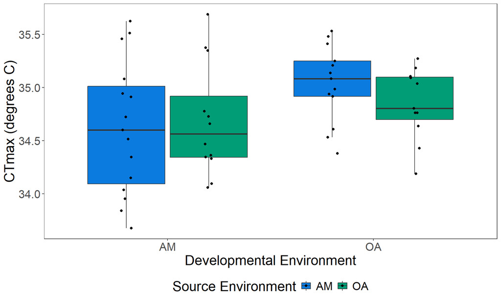

```r
ggplot(use_am_oa, aes(x=treatment, y = ctmax, fill = ancestral))+
  geom_boxplot(outlier.colour = NA,  position = position_dodge(width = 0.8)) +
  geom_point(position = position_jitterdodge(jitter.width = 0.1, dodge.width = 0.8)) +
  labs(x = "Developmental Environment", y = "CTmax (degrees C)")+
  theme_bw()+
  theme(panel.grid.major = element_blank(), panel.grid.minor = element_blank(), text = element_text(size=20), legend.position = "bottom")+
  scale_fill_manual(values = lineage_cols)+
  guides(fill=guide_legend(title="Source Environment"))
```

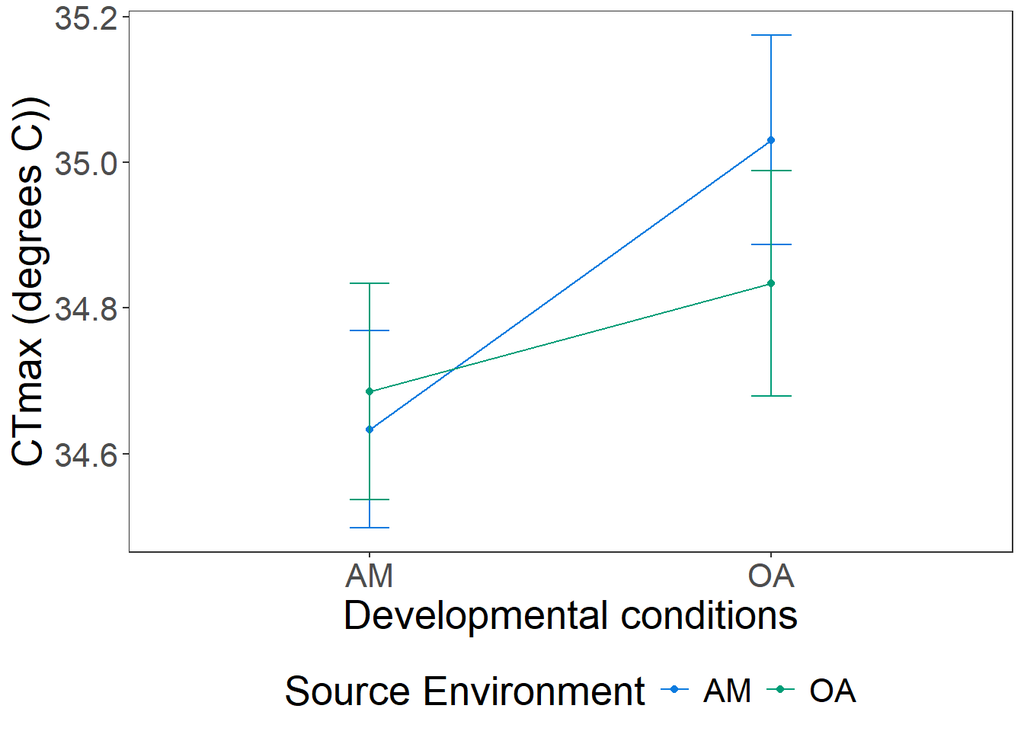

```r
am_oa_CL <- as.data.frame(em_am_oa[1])
colnames(am_oa_CL) <- c("treatment", "ancestral",  "CTmax", "SE", "df", "lcl","ucl")

rxn_norms_OA <- ggplot(am_oa_CL, aes(x=treatment, y=CTmax, color=ancestral))+
  geom_point( )+
  stat_summary(aes(group = ancestral), fun = mean, geom = "path")+
  geom_errorbar(aes(ymin=CTmax-SE, ymax=CTmax+SE), width=.1) +
  theme_bw()+theme(panel.grid.major = element_blank(), panel.grid.minor = element_blank(), text = element_text(size=20), legend.position = "bottom")+
  scale_color_manual(values = lineage_cols)+
  labs(y= "CTmax (degrees C))", x = "Developmental conditions")+
  guides(color=guide_legend(title="Source Environment"))

rxn_norms_OA
```

# OW-AM Transplants

### Sample size

There were approxiametly 20 individuals per treatment.

```r
use_am_ow %>%
  count(lineage) %>%
  knitr::kable()
```

| data_set | lineage | n |
| --- | --- | --- |
| AM-OW | AM-AM | 20 |
| AM-OW | AM-OW | 20 |
| AM-OW | OW-AM | 20 |
| AM-OW | OW-OW | 18 |

```r
use_am_ow$replicate_ID= as.factor(use_am_ow$replicate_ID)
use_am_ow$treatment= as.factor(use_am_ow$treatment)
use_am_ow$ancestral= as.factor(use_am_ow$ancestral)
```

Every replicate/lineage was represented.

```r
table(use_am_ow$lineage, use_am_ow$replicate)
```

```
##
##         1 2 3 4
##   AM-AM 5 5 5 5
##   AM-OW 4 5 5 6
##   OW-AM 5 5 2 8
##   OW-OW 4 5 5 4
```

### Statistical Analysis

```r
em_am_ow <- emmeans(ctmax.model_am_ow, pairwise~treatment*ancestral)
letter_display_am_ow <- multcomp::cld(em_am_ow, Letters = c(LETTERS))

kable(emmeans(ctmax.model_am_ow, pairwise~treatment*ancestral)$contrasts)
```

[output not shown]

| contrast | estimate | SE | df | t.ratio | p.value |
| --- | --- | --- | --- | --- | --- |
| AM AM - OW AM | -0.8316725 | 0.1891551 | 70.92363 | -4.3967746 | 0.0002178 |
| AM AM - AM OW | -0.2185197 | 0.2327580 | 12.08689 | -0.9388279 | 0.7850785 |
| AM AM - OW OW | -0.3364930 | 0.2366811 | 12.90996 | -1.4217147 | 0.5087892 |
| OW AM - AM OW | 0.6131527 | 0.2358661 | 11.95022 | 2.5995794 | 0.0938667 |
| OW AM - OW OW | 0.4951795 | 0.2397383 | 12.75190 | 2.0655000 | 0.2159765 |
| AM OW - OW OW | -0.1179732 | 0.1909959 | 68.52690 | -0.6176742 | 0.9261021 |

### Visual Analysis

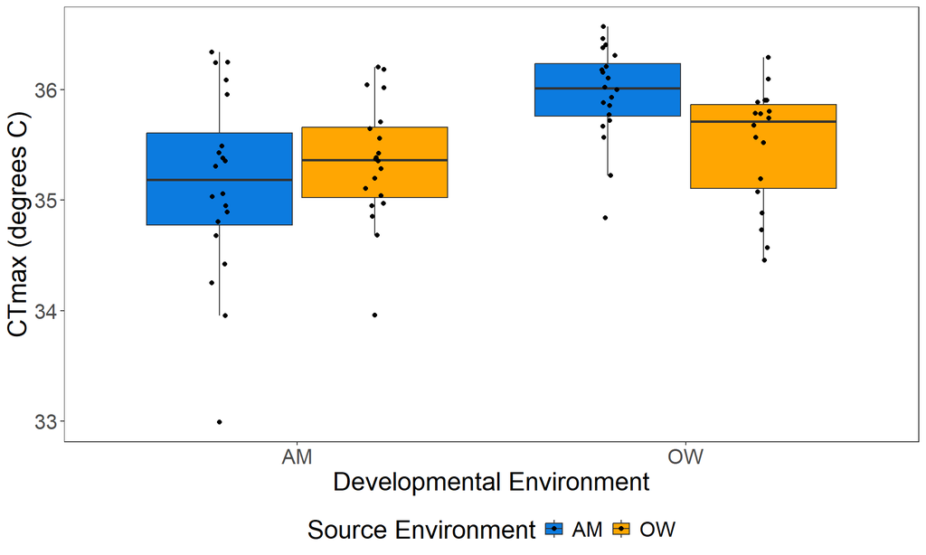

```r
ggplot(use_am_ow, aes(x=treatment, y = ctmax, fill = ancestral))+
  geom_boxplot(outlier.colour = NA,  position = position_dodge(width = 0.8)) +
  geom_point(position = position_jitterdodge(jitter.width = 0.1, dodge.width = 0.8)) +
  labs(x = "Developmental Environment", y = "CTmax (degrees C)")+
  theme_bw()+
  theme(panel.grid.major = element_blank(), panel.grid.minor = element_blank(), text = element_text(size=20), legend.position = "bottom")+
  scale_fill_manual(values = lineage_cols)+
  guides(fill=guide_legend(title="Source Environment"))
```

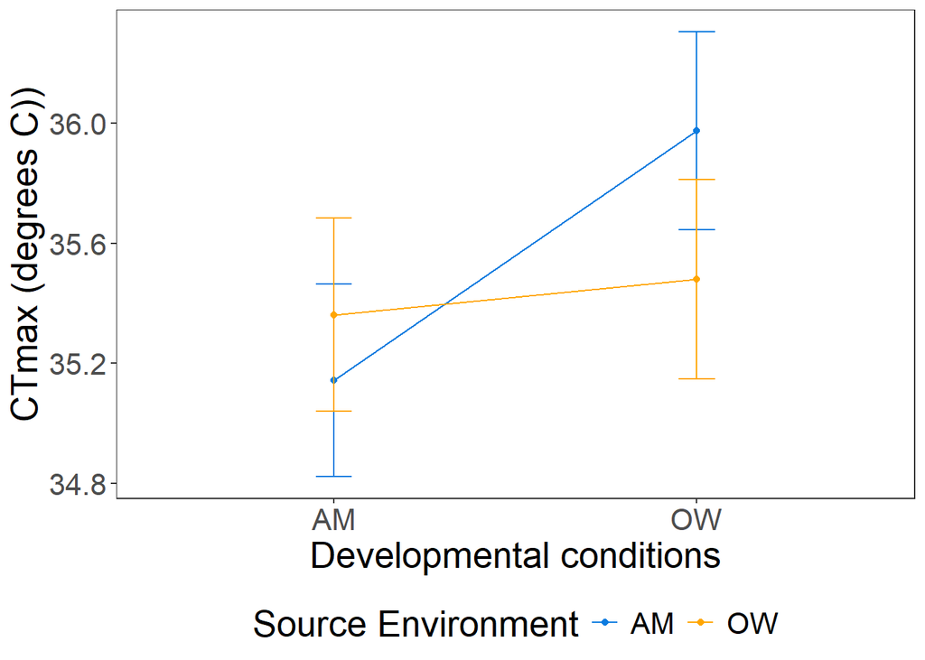

```r
am_ow_CL <- as.data.frame(em_am_ow[1])
colnames(am_ow_CL) <- c("treatment", "ancestral",  "CTmax", "SE", "df", "lcl","ucl")

rxn_norms_OW <- ggplot(am_ow_CL, aes(x=treatment, y=CTmax, color=ancestral))+
  geom_point( )+
  stat_summary(aes(group = ancestral), fun.y = mean, geom = "path")+
  geom_errorbar(aes(ymin=CTmax-1.95*SE, ymax=CTmax+1.95*SE), width=.1) +
  theme_bw()+theme(panel.grid.major = element_blank(), panel.grid.minor = element_blank(), text = element_text(size=20), legend.position = "bottom")+
  scale_color_manual(values = lineage_cols)+
  labs(y= "CTmax (degrees C))", x = "Developmental conditions")+
  guides(color=guide_legend(title="Source Environment"))

rxn_norms_OW
```

# OWA-OW transplants

### Sample Size

There were approximately 20 individuals per treatment.

```r
use_ow_owa %>%
  count(lineage) %>%
  knitr::kable()
```

| data_set | lineage | n |
| --- | --- | --- |
| OW-OWA | OW-OW | 20 |
| OW-OWA | OW-OWA | 19 |
| OW-OWA | OWA-OW | 20 |
| OW-OWA | OWA-OWA | 18 |

```r
table(use_ow_owa$lineage, use_ow_owa$replicate)
```

```
##
##           1 2 3 4
##   OW-OW   5 5 5 5
##   OW-OWA  3 9 3 4
##   OWA-OW  5 5 5 5
##   OWA-OWA 5 0 5 8
```

### Statistical Analysis

```r
ctmax.model_ow_owa = nlme::lme(fixed = ctmax ~ ancestral*treatment,
                        random = ~1|replicate_ID,
                        data = use_ow_owa)
kable(anova(ctmax.model_ow_owa))
```

|  | numDF | denDF | F-value | p-value |
| --- | --- | --- | --- | --- |
| (Intercept) | 1 | 67 | 3.750380e+05 | 0.0000000 |
| ancestral | 1 | 6 | 2.336770e-02 | 0.8835160 |
| treatment | 1 | 67 | 5.472697e-01 | 0.4620198 |
| ancestral:treatment | 1 | 67 | 1.269207e-01 | 0.7227658 |

```r
shapiro.test(residuals(ctmax.model_ow_owa))
```

```
##
##  Shapiro-Wilk normality test
##
## data:  residuals(ctmax.model_ow_owa)
## W = 0.98617, p-value = 0.5723
```

```r
leveneTest(ctmax ~ ancestral*treatment, as.data.frame(use_ow_owa))
```

```
## Levene's Test for Homogeneity of Variance (center = median)
##       Df F value Pr(>F)
## group  3  1.0189 0.3894
##       73
```

```r
em_ow_owa <- emmeans(ctmax.model_ow_owa, pairwise~ancestral*treatment)
letter_display_ow_owa <- multcomp::cld(em_ow_owa, Letters = c(LETTERS))

kable(emmeans(ctmax.model_ow_owa, pairwise~ancestral*treatment)$contrasts)
```

| contrast | estimate | SE | df | t.ratio | p.value |
| --- | --- | --- | --- | --- | --- |
| OW OW - OWA OW | 0.0243932 | 0.1643599 | 6 | 0.1484133 | 0.9987020 |
| OW OW - OW OWA | 0.1265786 | 0.1622391 | 67 | 0.7801980 | 0.8631628 |
| OW OW - OWA OWA | 0.0675752 | 0.1666848 | 6 | 0.4054068 | 0.9755299 |
| OWA OW - OW OWA | 0.1021854 | 0.1643599 | 6 | 0.6217172 | 0.9214296 |
| OWA OW - OWA OWA | 0.0431820 | 0.1687498 | 67 | 0.2558933 | 0.9940682 |
| OW OWA - OWA OWA | -0.0590035 | 0.1666848 | 6 | -0.3539822 | 0.9833627 |

### Visual Analysis

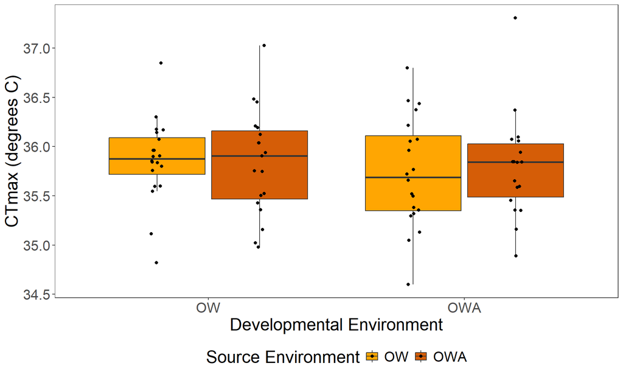

```r
ggplot(use_ow_owa, aes(x=treatment, y = ctmax, fill = ancestral))+
  geom_boxplot(outlier.colour = NA,  position = position_dodge(width = 0.8)) +
  geom_point(position = position_jitterdodge(jitter.width = 0.1, dodge.width = 0.8)) +
  labs(x = "Developmental Environment", y = "CTmax (degrees C)")+
  theme_bw()+
  theme(panel.grid.major = element_blank(), panel.grid.minor = element_blank(), text = element_text(size=20), legend.position = "bottom")+
  scale_fill_manual(values = lineage_cols)+
  guides(fill=guide_legend(title="Source Environment"))
```

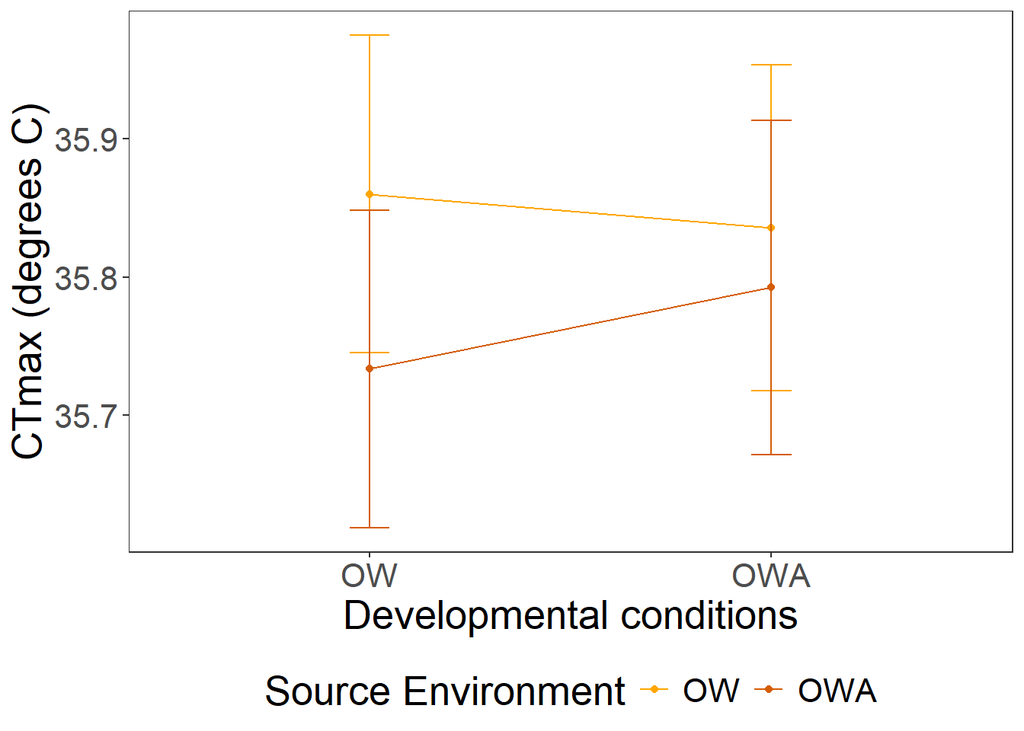

```r
ow_owa_CL <- as.data.frame(em_ow_owa[1])
colnames(ow_owa_CL) <- c("treatment", "ancestral",  "CTmax", "SE", "df", "lcl","ucl")

rxn_norms_OWA <- ggplot(ow_owa_CL, aes(x=treatment, y=CTmax, color=ancestral))+
  geom_point()+
  stat_summary(aes(group = ancestral), fun.y = mean, geom = "path")+
  geom_errorbar(aes(ymin=CTmax-SE, ymax=CTmax+SE), width=.1) +
  theme_bw()+theme(panel.grid.major = element_blank(), panel.grid.minor = element_blank(), text = element_text(size=20), legend.position = "bottom")+
  scale_color_manual(values = lineage_cols)+
  labs(y= "CTmax (degrees C)", x = "Developmental conditions")+
  guides(color=guide_legend(title="Source Environment"))


 rxn_norms_OWA
```

# Bin Effects

```r
use_data <- bind_rows(lineages, use_am_oa, use_am_ow, use_ow_owa)
```

```r
bins_lm <- function(df){
  #leveneTest(ctmax~replicate_ID, data=df)
  anova(lm(ctmax~replicate_ID, data=df))
}

bin_comparisons <- use_data %>%
  group_by(lineage, data_set) %>%
  nest() %>%
  mutate(results=map(data, bins_lm)) %>%
  mutate(p_value=(as.data.frame(results) %>% pull('Pr..F.'))[1])

kable(bin_comparisons %>% dplyr::select(-data, -results))
```

| data_set | lineage | p_value |
| --- | --- | --- |
| 4_lineages | OWA | 0.7643140 |
| 4_lineages | AM | 0.2501732 |
| 4_lineages | OW | 0.9042892 |
| 4_lineages | OA | 0.1073893 |
| AM-OA | AM-OA | 0.0659373 |
| AM-OA | AM-AM | 0.3446609 |
| AM-OA | OA-AM | 0.2650995 |
| AM-OA | OA-OA | 0.4585415 |
| AM-OW | AM-OW | 0.0027552 |
| AM-OW | OW-OW | 0.3618443 |
| AM-OW | AM-AM | 0.1396290 |
| AM-OW | OW-AM | 0.0195093 |
| OW-OWA | OW-OW | 0.7530000 |
| OW-OWA | OWA-OW | 0.4405916 |
| OW-OWA | OWA-OWA | 0.3202972 |
| OW-OWA | OW-OWA | 0.1998988 |

# Analysis of all transplants with one model

```r
transplants <- bind_rows( use_am_oa, use_am_ow, use_ow_owa) %>%
  mutate(treatment_temp =ifelse(treatment %in% c("OW", "OWA"), "22", "18"),
         treatment_acidif =ifelse(treatment %in% c("OA", "OWA"), "high", "ambiant"),
         assay = str_c(data_set, run, sep="-"))
```

```r
options(contrasts=c("contr.treatment","contr.poly"))
#The default reference levels for contr.treatment are AM for lineage, 18 for temperature and ambiant pH.

transplants$treatment_temp <- as.factor(transplants$treatment_temp)
transplants$treatment_acidif <- as.factor(transplants$treatment_acidif)
transplantsancestral <- as.factor(transplants$ancestral)

transplants_model <- lme4::lmer(ctmax~ancestral+treatment_temp+treatment_acidif +ancestral:treatment_temp + ancestral:treatment_acidif +  (1|assay), data=transplants)

#Assay is which CTmax run but coded so that each data set has a unique value for. E.g. AM-OW run 1 has no relationshio to AM-OA run 1.

summary(transplants_model)
```

```
## Linear mixed model fit by REML ['lmerMod']
## Formula: ctmax ~ ancestral + treatment_temp + treatment_acidif + ancestral:treatment_temp +      ancestral:treatment_acidif + (1 | assay)
##    Data: transplants
##
## REML criterion at convergence: 344
##
## Scaled residuals:
##     Min      1Q  Median      3Q     Max
## -3.8711 -0.5204  0.0369  0.6046  2.5330
##
## Random effects:
##  Groups   Name        Variance Std.Dev.
##  assay    (Intercept) 0.07743  0.2783
##  Residual             0.25751  0.5075
## Number of obs: 206, groups:  assay, 22
##
## Fixed effects:
##                                   Estimate Std. Error t value
## (Intercept)                       34.85297    0.12509 278.619
## ancestralOA                       -0.04007    0.18544  -0.216
## ancestralOW                        0.62811    0.20568   3.054
## ancestralOWA                       0.04393    0.24355   0.180
## treatment_temp22                   0.93559    0.15200   6.155
## treatment_acidifhigh               0.30672    0.18172   1.688
## ancestralOW:treatment_temp22      -0.74486    0.21752  -3.424
## ancestralOA:treatment_acidifhigh  -0.11491    0.28008  -0.410
## ancestralOW:treatment_acidifhigh  -0.35811    0.23719  -1.510
## ancestralOWA:treatment_acidifhigh -0.35871    0.24730  -1.451
##
## Correlation of Fixed Effects:
##             (Intr) ancsOA ancsOW ancOWA trt_22 trtmn_ aOW:_2 anOA:_ anOW:_
## ancestralOA -0.389
## ancestralOW -0.608  0.236
## ancestrlOWA -0.308  0.120  0.188
## trtmnt_tm22 -0.329  0.128  0.200 -0.455
## trtmnt_cdfh -0.400  0.374  0.243  0.123  0.131
## ancstOW:_22  0.230 -0.089 -0.524  0.318 -0.699 -0.092
## ancstrlOA:_  0.257 -0.655 -0.156 -0.079 -0.084 -0.646  0.059
## ancstrlOW:_  0.306 -0.286 -0.264 -0.095 -0.101 -0.766  0.016  0.495
## ancstrOWA:_  0.294 -0.275 -0.179 -0.319 -0.097 -0.735  0.068  0.475  0.563
## fit warnings:
## fixed-effect model matrix is rank deficient so dropping 2 columns / coefficients
```

```r
car::Anova(transplants_model, type="III")
```

```
## Analysis of Deviance Table (Type III Wald chisquare tests)
##
## Response: ctmax
##                                 Chisq Df Pr(>Chisq)
## (Intercept)                77628.4408  1  < 2.2e-16 ***
## ancestral                     10.3628  3  0.0157212 *
## treatment_temp                37.8850  1  7.504e-10 ***
## treatment_acidif               2.8489  1  0.0914356 .
## ancestral:treatment_temp      11.7255  1  0.0006165 ***
## ancestral:treatment_acidif     3.1783  3  0.3649468
## ---
## Signif. codes:  0 '***' 0.001 '**' 0.01 '*' 0.05 '.' 0.1 ' ' 1
```

```r
emm_trans <- emmeans(transplants_model, pairwise~ancestral*treatment_temp*treatment_acidif)
means_trans <- as.data.frame(emm_trans[1])

contrasts_pH <- as.data.frame(emmeans(transplants_model, pairwise~treatment_acidif | ancestral)[2]) %>% mutate(contrasts.estimate = -1*contrasts.estimate)
contrasts_temp <- as.data.frame(emmeans(transplants_model, pairwise~treatment_temp | ancestral)[2]) %>% drop_na() %>% mutate(contrasts.estimate = -1*contrasts.estimate)



#Testing model assumptions
#ranef(transplants_model)
shapiro.test(residuals(transplants_model))
```

```
##
##  Shapiro-Wilk normality test
##
## data:  residuals(transplants_model)
## W = 0.988, p-value = 0.08063
```

```r
leveneTest(ctmax~ancestral*treatment_temp*treatment_acidif, as.data.frame(transplants), center=mean)
```

```
## Levene's Test for Homogeneity of Variance (center = mean)
##        Df F value  Pr(>F)
## group   9  2.1229 0.02928 *
##       196
## ---
## Signif. codes:  0 '***' 0.001 '**' 0.01 '*' 0.05 '.' 0.1 ' ' 1
```

# Figures for Publication

The Y axis represents the difference in mean between the high and low treatment (e.g. for temperature the differences is CTmax at 22 - CTmax at 18. )

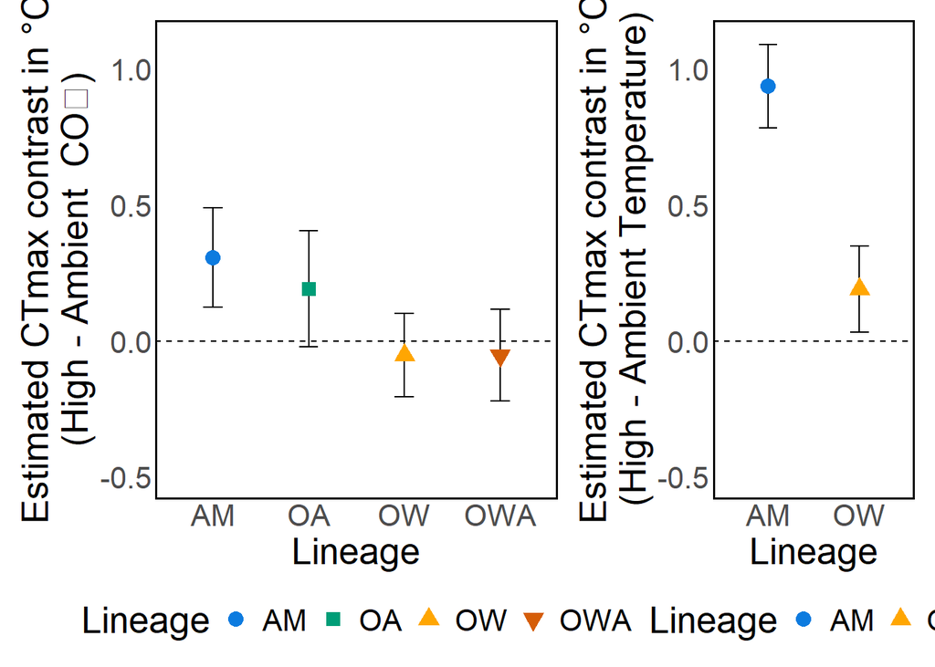

```r
colnames(contrasts_pH) <- c("contrasts", "lineage", "difference",  "SE",  "df", "t.ratio", "p.value")
colnames(contrasts_temp) <- c("contrasts", "lineage", "difference",  "SE",  "df", "t.ratio", "p.value")


contrast_pH_plot <- ggplot(contrasts_pH, aes(x=lineage, y=difference))+
  geom_errorbar(aes(ymin=difference-SE, ymax=difference+SE),width=.2)+
  geom_point(size=3.5, aes(color=lineage, fill=lineage, shape=lineage))+
  scale_color_manual(values = lineage_cols)+
  scale_fill_manual(values = lineage_cols)+
  scale_shape_manual(values = c(21, 22, 24, 25)) +
  geom_hline(yintercept = 0, linetype = "dashed")+
  scale_y_continuous(limits = c(-.5, 1.1))+
    labs(y= 'Estimated CTmax contrast in °C\n(High - Ambient  CO₂)', x = "Lineage", color='Lineage', shape= 'Lineage', fill= 'Lineage')+
  theme(panel.grid.major = element_blank(), panel.grid.minor = element_blank(),
    panel.background = element_rect(fill = "white"),
    text = element_text(size = 20),
    panel.border = element_rect(fill=NA, linewidth = 1, colour = "black"), legend.position = "bottom",
    axis.ticks.x = element_blank(), axis.ticks.y = element_blank(),
        strip.text = element_blank())

contrast_temp_plot <- ggplot(contrasts_temp, aes(x=lineage, y=difference))+
  geom_errorbar(aes(ymin=difference-SE, ymax=difference+SE),width=.2)+
  geom_point(size=3.5, aes(color=lineage, fill=lineage, shape=lineage))+
  scale_color_manual(values = lineage_cols)+
  scale_fill_manual(values = lineage_cols)+
  scale_shape_manual(values = c(21, 24)) +
  geom_hline(yintercept = 0, linetype = "dashed")+
  scale_y_continuous(limits = c(-.5, 1.1))+
  labs(y= 'Estimated CTmax contrast in °C\n(High - Ambient Temperature)', x = "Lineage", color='Lineage', shape= 'Lineage', fill= 'Lineage')+
  theme(panel.grid.major = element_blank(), panel.grid.minor = element_blank(),
    panel.background = element_rect(fill = "white"),
    text = element_text(size = 20),
    panel.border = element_rect(fill=NA, linewidth = 1, colour = "black"), legend.position = "bottom",
    axis.ticks.x = element_blank(), axis.ticks.y = element_blank(),
        strip.text = element_blank())

combined_contrast_plot <- contrast_pH_plot + contrast_temp_plot + plot_layout(widths = c(2,1))
combined_contrast_plot
```

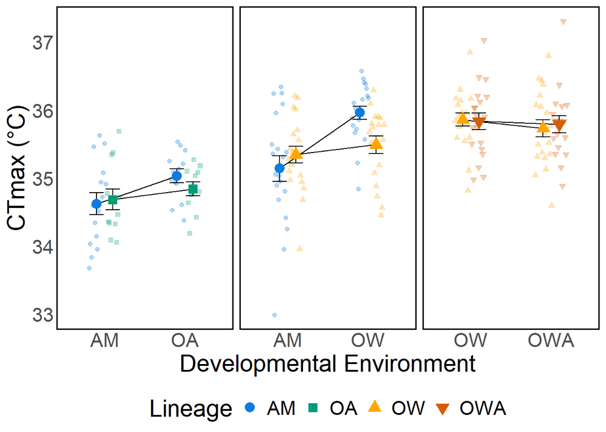

```r
transplants_raw_rxn_norms <- transplants %>% group_by(data_set, lineage) %>% mutate(mean_ctmax= mean(ctmax), SE=sd(ctmax)/sqrt(n())) %>% dplyr::select(treatment, ancestral, lineage, data_set, mean_ctmax, SE) %>% unique()
transplants_raw_rxn_norms$data_set <- as.factor(transplants_raw_rxn_norms$data_set)
transplants_raw_rxn_norms$ancestral <- as.factor(transplants_raw_rxn_norms$ancestral)

transplants_raw_rxn_norms <- transplants_raw_rxn_norms %>% ungroup() %>% complete(data_set, ancestral)

combined_raw_rxn_norm_plot <- ggplot(transplants_raw_rxn_norms %>%  filter(!is.na(mean_ctmax)) , aes(x=treatment, y=mean_ctmax))+
  facet_wrap(~data_set, scales="free_x")+
  geom_point(data=transplants, aes(x=treatment, y=ctmax, color=ancestral, shape=ancestral, fill=ancestral), position=position_dodge2(width=0.4), alpha=.3)+
  stat_summary(aes(group = ancestral), fun.y = mean, geom = "path", position=position_dodge2(width=0.4))+
  geom_errorbar(aes(ymin=mean_ctmax-SE, ymax=mean_ctmax+SE),
                position=position_dodge2(width=0.4), width=.4) +
  theme_bw()+
  geom_point(size=3.5, aes(color=ancestral, shape=ancestral, fill=ancestral), position=position_dodge2(width=0.4))+
  scale_shape_manual(values = c(21, 22, 24, 25)) +
  scale_color_manual(values = lineage_cols)+
  scale_fill_manual(values = lineage_cols)+
  labs(y= 'CTmax (°C)', x = "Developmental Environment", color='Lineage', shape= 'Lineage', fill= 'Lineage') +
  theme(panel.grid.major = element_blank(), panel.grid.minor = element_blank(),
        text = element_text(size=20), legend.position = "bottom",
        panel.border = element_rect(linewidth = 1, colour = "black"),
        axis.ticks.x = element_blank(), axis.ticks.y = element_blank(),
        strip.text = element_blank())

combined_raw_rxn_norm_plot
```

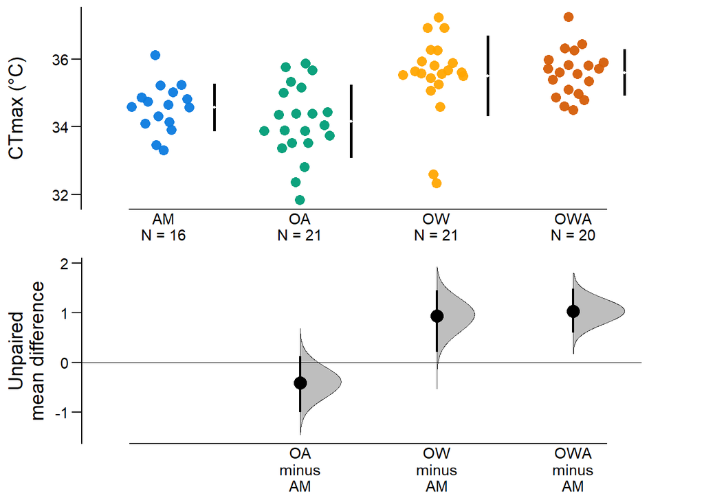

```r
#This code works only with version 0.3.0 of dabestr. The functionality to change plot colors is not present in the current version of dabestr.


mean_diff = lineages %>%
  dabest(lineage, ctmax,
         idx = c("AM", "OA", "OW", "OWA"),
         paired = FALSE) %>% mean_diff()
plot(mean_diff,
     rawplot.markersize = 3,
     palette = lineage_cols,
     rawplot.ylabel = "CTmax (°C)")
```